# Economic and health costs of weather events in the United States: an analysis of NOAA data

Susannah Fleming

19 September 2015

Severe weather can result in considerable costs to the community, both in terms of human costs due to fatalities and injuries, and economic costs from damage to property and crops. We investigated the average yearly cost of severe weather in terms of both human health, and economic costs due to damage.

In terms of human health, tornadoes cause the most harm, with an average of just over 1500 people killed or injured per year. This is followed by high temperatures, which kill or injure an average of over 650 people per year.

## Data processing

The data is downloaded from the coursera website as a zipped csv file.

```r
download.file("https://d396qusza40orc.cloudfront.net/repdata%2Fdata%2FStormData.csv.bz2","StormData.csv.bz2",method="curl")
stormdat <- read.csv("StormData.csv.bz2")
```

We know that different events started to be reported at different times, so it would be useful to have a column for the year. I’m going to use the start date to define the year of the event.

```r
posixdate <- strptime(as.character(stormdat$BGN_DATE),format="%m/%d/%Y %H:%M:%S")
stormdat$YEAR <- format(posixdate,"%Y")
```

### Multipliers for crop and property damage

The data on crop and property damage has a separate multiplier code ending “EXP”. We know that K (and presumably k) means x10^3, M (m) means x10^6, and B means x10^9 (assuming US definition of “billion”.) Where no multiplier is specified, we can assume that this is x1. However, there are a number of other multipliers that are incompletely specified (e.g. ?, -, +, 0, 1, 2, 3, 4, 5, 6, 7, 8, h, H.)

I am going to investigate how many of these there are, and what sort of values are associated with them.

```r
# economic consequences
pdx <- stormdat$PROPDMGEXP
pdoddexp <- which(pdx!="M" & pdx!="m" & pdx!="k" & pdx!="K" & pdx!="B" & pdx!="")
cdx <- stormdat$CROPDMGEXP
cdoddexp <- which(cdx!="M" & cdx!="m" & cdx!="k" & cdx!="K" & cdx!="B" & cdx!="")
length(pdoddexp)
```

```
## [1] 321
```

```r
length(cdoddexp)
```

```
## [1] 27
```

### Filtering the data

Since there are only a few of these undefined values, and there is no explanation of what they correspond to, I’m going to remove them from the analysis.

I am also going to remove events with none of the outcomes of interest - i.e. zero fatalites, zero injuries, and zero crop and property damage

```r
toremovemult=unique(c(cdoddexp,pdoddexp))
stormdat <- stormdat[-toremovemult,]

noOutcomes <- which(stormdat$FATALITIES==0 & stormdat$INJURIES==0
                    & stormdat$CROPDMG==0 & stormdat$PROPDMG==0)
stormdat <- stormdat[-noOutcomes,]
```

### Creating a tidy data set

I want a useful set of weather types, fatalities, injuries, crop damage, and property damage.

First, I will convert the crop and property damage values to take account of the exponentials.

```r
# multipliers for crop damage
stormdat$MULTCROP <- stormdat$CROPDMG
cropK <- which(stormdat$CROPDMGEXP=="k" | stormdat$CROPDMGEXP=="K")
stormdat$MULTCROP[cropK] <- stormdat$MULTCROP[cropK]*1e3
cropM <- which(stormdat$CROPDMGEXP=="m" | stormdat$CROPDMGEXP=="M")
stormdat$MULTCROP[cropM] <- stormdat$MULTCROP[cropM]*1e6
cropB <- which(stormdat$CROPDMGEXP=="B")
stormdat$MULTCROP[cropB] <- stormdat$MULTCROP[cropB]*1e9

# multipliers for property damage
stormdat$MULTPROP <- stormdat$PROPDMG
propK <- which(stormdat$PROPDMGEXP=="k" | stormdat$PROPDMGEXP=="K")
stormdat$MULTPROP[propK] <- stormdat$MULTPROP[propK]*1e3
propM <- which(stormdat$PROPDMGEXP=="m" | stormdat$PROPDMGEXP=="M")
stormdat$MULTPROP[propM] <- stormdat$MULTPROP[propM]*1e6
propB <- which(stormdat$PROPDMGEXP=="B")
stormdat$MULTPROP[propB] <- stormdat$MULTPROP[propB]*1e9
```

Then I need to map the EVTYPE to more useful (generic) event descriptors. There isn’t an obvious 1-1 mapping for this as some descriptors overlap (e.g. does THUNDERSTORM WINDS/HAIL come under thunderstorms, winds, or hail?) I’ve therefore chosen to classify in the following order:

1. events which are effects of severe weather (e.g. flooding, fire)
2. events which describe a weather system (e.g. thunderstorm)
3. non-weather causative events (e.g. volcano, tides)
4. type of precipitation (snow, hail etc)
5. wind
6. cloud
7. temperature
8. other events which cannot be easily classified as above (e.g. drowning, undefined “storm”)

```r
f <- as.character(stormdat$EVTYPE)

# new codes start with x to allow filtering at end for "other" category

# effects of severe weather
f[grep("flood|rising water",f,ignore.case=T)] <- "xFlood"
f[grep("fire|smoke",f,ignore.case = T)] <- "xFire"
f[grep("tsunami",f,ignore.case = T)] <- "xTsunami"

# weather system
f[grep("thunder|lightn|thuder|thudeer|thuner|lignt",ignore.case = T,f)] <-
  "xThunderstorm"
f[grep("tornado|waterspout|dust devil|whirl|spout",f,ignore.case = T)] <-
  "xTornado"
f[grep("^tstm|tropical|^ tstm|marine tstm|typhoon",f,ignore.case = T)] <- "xTropical storm"

# not weather
f[grep("volc",f,ignore.case = T)] <- "xVolcano"
f[grep("tide|surf|seas$|current|swell",f,ignore.case = T)] <- "xSea conditions"

# precipitation
f[grep("snow|blizzard|avalan",f,ignore.case = T)] <- "xSnow"
f[grep("hail",f,ignore.case = T)] <- "xHail"
f[grep("sleet|rain|wet|drizz|precip",f,ignore.case = T)] <- "xRain/Sleet"

# wind
f[grep("wind|hurricane|blow",f,ignore.case = T)] <- "xWind - other"

# cloud
f[grep("fog",f, ignore.case = T)] <- "xFog"

# temperature
f[grep("heat|warm|hyperthermia",f,ignore.case=T)] <- "xHigh temperature"
f[grep("cold|freez|wint|ice|hypothermia|frost|icy",f,ignore.case = T)] <-
  "xLow temperature"

# capture remaining that should have been classified
f[grep("wave",f,ignore.case = T)] <- "xSea conditions"

# everything else
f[grep("^[a-w]|^[y-z]|\\?",f,ignore.case=T)] <- "xOther"

f <- gsub("^x","",f)

stormdat$EVENTCAT <- f
```

Now I can create my tidy data set for analysis.

```r
tidydata <- with(stormdat,
                 data.frame(EventType=EVENTCAT,Year=YEAR,Fatalities=FATALITIES,
                            Injuries=INJURIES,CropDamage=MULTCROP,
                            PropertyDamage=MULTPROP))
```

## Results

We are aiming to answer the following two questions:

1. Across the United States, which types of events (as indicated in the EVTYPE variable) are most harmful with respect to population health?
2. Across the United States, which types of events have the greatest economic consequences?

Since different events are reported in different years, I am going to look at the total harm or cost per year, rather than totalling over the years. Where there are no events in a year, that year will not contribute to the analysis.

### Which events are most harmful to health?

It is difficult to quantify the relative “harm” from injuries and fatalities: injuries can cost more in monetary terms (e.g. ongoing medical treatment, welfare costs if unable to work.) However, fatalities are also costly in terms of lost income, and people who ultimately die may require significant input from rescue and medical teams, whereas some injuries may be minor (e.g. sprains.)

Without any further information on the impact of individual fatalities and injuries, which is outside the scope of this data, I will simply sum the numbers of injuries and fatalities from an event to determine “harm to health.”

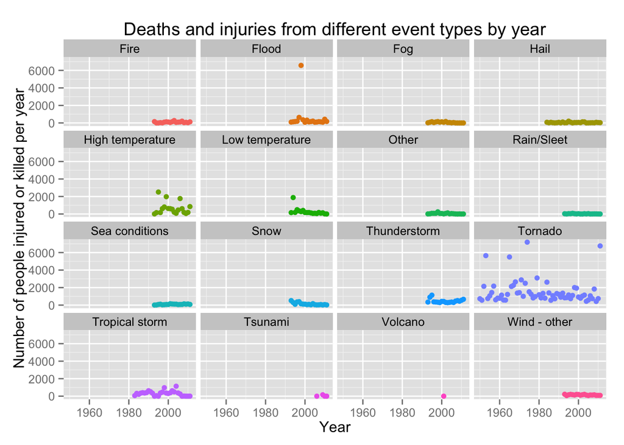

```r
library(dplyr)
library(ggplot2)

tidydata$HealthHarm <- tidydata$Injuries + tidydata$Fatalities
HarmByYear <- tidydata %>% group_by(Year,EventType) %>%
  summarise(Harm=sum(HealthHarm))
HarmByYear$YearNum <- as.numeric(as.character(HarmByYear$Year))

healthplot <- ggplot(HarmByYear, aes(YearNum,Harm,colour=EventType))
healthplot <- healthplot + geom_point() + facet_wrap(~EventType,4,4)
healthplot <- healthplot + theme(legend.position="none")
healthplot <- healthplot + xlab("Year") + ylab("Number of people injured or killed per year")
healthplot <- healthplot + ggtitle("Deaths and injuries from different event types by year")
print(healthplot)
```

```r
avHarm <- HarmByYear %>% group_by(EventType) %>%
  summarise(AverageYearlyAffected=mean(Harm))
avHarm <- avHarm[order(-avHarm$AverageYearlyAffected),]
maxharm <- avHarm[1,]

avHarm
```

```
## Source: local data frame [16 x 2]
##
##           EventType AverageYearlyAffected
## 1           Tornado            1566.41935
## 2  High temperature             653.78947
## 3             Flood             533.15789
## 4      Thunderstorm             459.94737
## 5    Tropical storm             323.31034
## 6   Low temperature             264.36842
## 7      Wind - other             143.57895
## 8              Snow             138.26316
## 9              Fire              89.36842
## 10   Sea conditions              82.52632
## 11              Fog              60.94737
## 12            Other              53.52632
## 13             Hail              49.39286
## 14          Tsunami              40.50000
## 15       Rain/Sleet              24.10526
## 16          Volcano               0.00000
```

The average yearly total of fatalities and injuries by event type is given in the table above, which is sorted from most to least harmful. The event type with the most fatalities and injuries in an average year is therefore Tornado, with an average of 1566.4 people affected.

### Which events have most economic impact?

I sum the costs of both property and crop damage to assess economic impact.

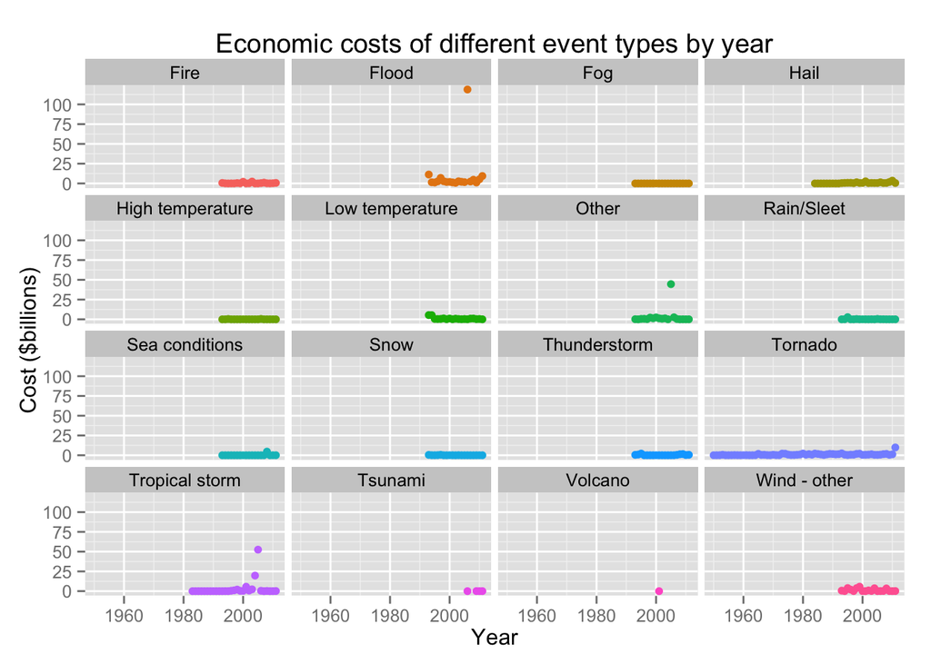

```r
tidydata$EconomicImpact <- tidydata$CropDamage + tidydata$PropertyDamage

CostByYear <- tidydata %>% group_by(Year,EventType) %>%
  summarise(Cost=sum(EconomicImpact)/1e9) # amount in billions of dollars
CostByYear$YearNum <- as.numeric(as.character(CostByYear$Year))

costplot <- ggplot(CostByYear, aes(YearNum,Cost,colour=EventType))
costplot <- costplot + geom_point() + facet_wrap(~EventType,4,4)
costplot <- costplot + theme(legend.position="none")
costplot <- costplot + xlab("Year") + ylab("Cost ($billions)") + ggtitle("Economic costs of different event types by year")
print(costplot)
```

```r
avCosts <- CostByYear %>% group_by(EventType) %>%
  summarise(BillionsOfDollars=mean(Cost))
avCosts <- avCosts[order(-avCosts$BillionsOfDollars),]
maxcost <- avCosts[1,]

avCosts
```

```
## Source: local data frame [16 x 2]
##
##           EventType BillionsOfDollars
## 1             Flood       9.468861034
## 2             Other       3.093664453
## 3    Tropical storm       2.968548393
## 4      Wind - other       1.336620232
## 5   Low temperature       1.011735577
## 6           Tornado       0.951140055
## 7              Hail       0.678444514
## 8              Fire       0.468684744
## 9      Thunderstorm       0.422711447
## 10   Sea conditions       0.251001658
## 11       Rain/Sleet       0.223561999
## 12             Snow       0.101924137
## 13 High temperature       0.048673949
## 14          Tsunami       0.036020500
## 15              Fog       0.001316395
## 16          Volcano       0.000500000
```

The average yearly economic impact in dollars for each event type is given in the table above, which is sorted from most to least expensive. The event type with the most economic impact in an average year is therefore Flood, with an average cost of $9.5 billion.

```r
floodcosts <- CostByYear[CostByYear$EventType=="Flood",]
badyear <- floodcosts[floodcosts$Cost==max(floodcosts$Cost),]
```

This is driven by a single year of particularly expensive flooding events in 2006, with floods in that year costing a total of $118.8 billion.

Below is a further analysis of yearly costs, with outlier years costing more than $25 billion removed from the analysis.

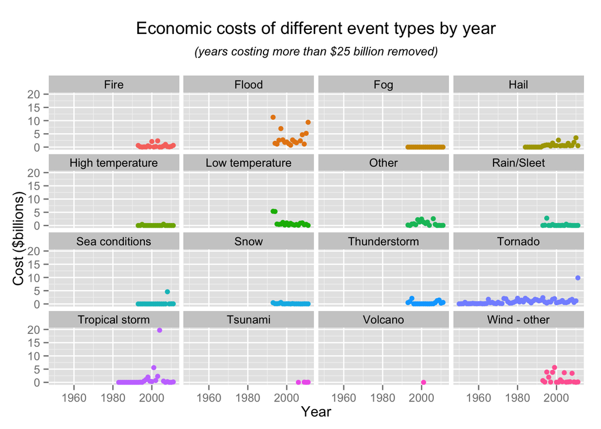

```r
outliers <- which(CostByYear$Cost>=25)
noOutliers <- CostByYear[-outliers,]

costplot2 <- ggplot(noOutliers, aes(YearNum,Cost,colour=EventType))
costplot2 <- costplot2 + geom_point() + facet_wrap(~EventType,4,4)
costplot2 <- costplot2 + theme(legend.position="none")
costplot2 <- costplot2 + xlab("Year") + ylab("Cost ($billions)")
costplot2 <- costplot2 + ggtitle(expression(atop(paste('Economic costs of different event types by year'), atop(italic(paste('(years costing more than $25 billion removed)')), ""))))
print(costplot2)
```

```r
avCosts2 <- noOutliers %>% group_by(EventType) %>%
  summarise(BillionsOfDollars=mean(Cost))
avCosts2 <- avCosts2[order(-avCosts2$BillionsOfDollars),]
maxcost2 <- avCosts2[1,]

avCosts2
```

```
## Source: local data frame [16 x 2]
##
##           EventType BillionsOfDollars
## 1             Flood       3.393535949
## 2      Wind - other       1.336620232
## 3    Tropical storm       1.199676760
## 4   Low temperature       1.011735577
## 5           Tornado       0.951140055
## 6             Other       0.791163367
## 7              Hail       0.678444514
## 8              Fire       0.468684744
## 9      Thunderstorm       0.422711447
## 10   Sea conditions       0.251001658
## 11       Rain/Sleet       0.223561999
## 12             Snow       0.101924137
## 13 High temperature       0.048673949
## 14          Tsunami       0.036020500
## 15              Fog       0.001316395
## 16          Volcano       0.000500000
```